# Análisis de Enriquecimiento Funcional con el paquete clusterProfiler

Sergio Cámara Peña

2022-06-23

# Introducción

El objetivo de este programa es, mediante el uso del paquete **clusterProfiler**[1], encontrar que términos se encuentran enriquecidos para los 3 **GO terms**:

- **Molecular Function** (MF)
- **Biological Process** (BP)
- **Cellular Component** (CC)

Esto, para cada uno de los 3 grupos que se han descrito en el documento de la memoria en relación a la enfermedad sobre la que se está trabajando en este proyecto, el **Carcinoma Escamoso de Cabeza y Cuello** (HNSCC). Para crear estos 3 grupos, nos fijamos en dos cosas. En primer lugar, se observa la relación que tiene la **metilación con el splicing alternativo (AS)**, para lo cual nos fijamos en el p-valor “**Pv_wilcox**”; y, en segundo lugar, se observa la relación que tiene la **metilación con la expresión**, para lo cual nos fijamos en el p-valor “**P.value**”.

Los 3 grupos generados son:

- **Metilación relacionada con Splicing Alternativo y Expresión** (AS y E)
- **Metilación relacionada con Splicing Alternativo, pero no con la Expresión** (AS y not E)
- **Metilación relacionada con Splicing Alternativo (aquí no ponemos foco en la expresión)** (AS related)

Nos centramos únicamente en estos grupos debido a que son los que más nos interesan de cara al objetivo final de nuestro proyecto, el cual pone el foco en relacionar *probes* de metilación con eventos de *splicing alternativo* que afectan de diversa manera en el desarrollo del HNSCC.

### ¿Cómo se llevó a cabo el proceso? ¿Cómo se deben analizar los resultados que se obtienen?

De cara a no sobrecargar este documento y para que quede explicado de forma concisa como se tienen que analizar los resultados y como es el proceso hasta su obtención, aquí se explicará siguiendo como modelo el caso del primer grupo generado (AS y E).

En primer lugar, tras haber leído y limpiado los datos, se empieza con el proceso que es único para cada grupo. Inicialmente, se filtran los datos para que queden únicamente aquellos genes que nos interesan para cada grupo. En este caso, queremos que la metilación esté relacionada con el splicing (**“Pv_wilcox” significativo**) y que la metilación esté relacionada con la expresión génica (**“P.Value” significativo**).

A continuación, una cosa importante que se hace es pasar de *gene symbol*, con el que el paquete **clusterProfiler** no puede trabajar, a **Entrez Gene ID** el cual es el *input* adecuado para este paquete.

Finalmente, ya que el proceso es repetitivo, nos fijaremos únicamente en una de las ontologías para explicar el proceso y analizar los resultados. Para ello nos centraremos en la ontología de **Celular Component** (CC).

#### Clasificación ontológica

Dada una lista de genes y utilizando la función **groupGO()**, se devuelve su perfil ontológico. Es decir, para cada gen se devuelven los términos ontológicos asociados y se cuenta cuantas veces aparece cada uno de estos términos en el conjunto de nuestros genes. A continuación, se representan en un **barplot** los 25 primeros resultados. Finalmente, se pasa al test de sobrerrepresentación.

#### Test de Sobrerrepresentación

Este test es un método estadístico que determina si los genes de conjuntos predefinidos (pertenecientes, por ejemplo, a un *Gene Ontology term* concreto) se encuentran más veces de lo que se podría esperar en el conjunto de tus datos [2].

**Nota**: Se puede ver en los test de sobrerrepresentación que los parámetros **pvalueCutoff** y **qvalueCutoff**, han recibido un valor de **0.05** y **0.2** respectivamente. Estos valores no son arbitrarios, sino que, son los que se recomiendan por defecto en la guía del paquete clusterProfiler.

Tras haber obtenido los resultados del test de sobrerrepresentación, en primer lugar, se grafican los términos más enriquecidos de nuestro conjunto de datos en un **barplot** junto a su p.valor asociado, hasta un máximo de 8 términos (parámetro por defecto). En segundo lugar, estos términos son representados en un **grafo** donde se muestra cómo se encuentran relacionados.

A continuación, una vez hechas las explicaciones previas, se exponen los resultados obtenidos para cada grupo junto con el código que se ha utilizado en cada caso para llegar a estos.

# Cargamos los paquetes necesarios para el programa

```r
library(clusterProfiler)
library(tidyverse)
library(org.Hs.eg.db)
```

# Lectura y limpieza de los datos

```r
Datos_originales <- read_delim("20222_01_21_Hit_wilcox_expr_Surv.csv",
                               delim = ";", escape_double = FALSE,
                               locale = locale(decimal_mark = ",",
                                               grouping_mark = "."),
                               trim_ws = TRUE)

Datos_limpios <- Datos_originales %>%
  dplyr::select(-c("...1","Pathway","Reference"))

Lista_total_genes <- unique(Datos_limpios$Gene)
```

# Grupo **Alternative Splicing and Expression related (AS y E)**

```r
AS_y_E_df <- Datos_limpios %>%
  dplyr::filter(Pv_wilcox < 0.05,
                P.Value < 0.05)

Lista_genes_AS_y_E <- unique(AS_y_E_df$Gene)

AS_y_E_ENTREZ <- mapIds(org.Hs.eg.db, Lista_genes_AS_y_E, 'ENTREZID', 'SYMBOL')
```

### **GO Celular Component** - GO classification

```r
gg_CC_AS_y_E <- groupGO(gene = AS_y_E_ENTREZ,
                        OrgDb = org.Hs.eg.db,
                        ont = "CC",
                        level = 3,
                        readable = TRUE)

head(gg_CC_AS_y_E)
```

```
##                    ID                Description Count GeneRatio geneID
## GO:0000133 GO:0000133                 polarisome     0     0/393
## GO:0000408 GO:0000408          EKC/KEOPS complex     0     0/393
## GO:0000417 GO:0000417                HIR complex     0     0/393
## GO:0000444 GO:0000444    MIS12/MIND type complex     0     0/393
## GO:0000808 GO:0000808 origin recognition complex     0     0/393
## GO:0000930 GO:0000930      gamma-tubulin complex     0     0/393
```

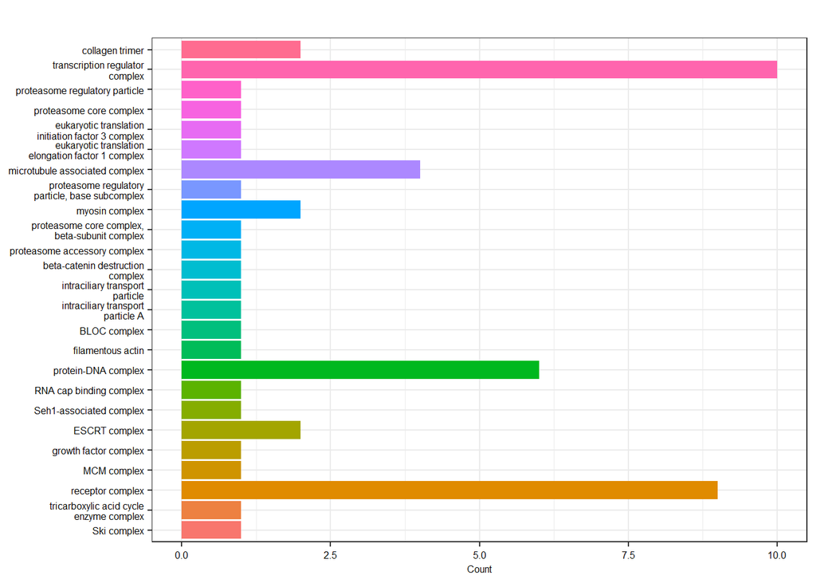

```r
barplot(gg_CC_AS_y_E, drop=TRUE, showCategory=25, vertex.label.cex=0.8, font = 6)
```

### **GO Celular Component** - Go Over-representation analysis

```r
go_overrepresentation_CC_AS_y_E <- enrichGO(gene = AS_y_E_ENTREZ,
                                            OrgDb = org.Hs.eg.db,
                                            ont = "CC",
                                            pAdjustMethod = "BH",
                                            pvalueCutoff = 0.05,
                                            qvalueCutoff = 0.2,
                                            readable = TRUE)
head(go_overrepresentation_CC_AS_y_E)
```

```
##                    ID            Description GeneRatio   BgRatio       pvalue
## GO:0005774 GO:0005774      vacuolar membrane    24/375 444/19550 5.670944e-06
## GO:0005765 GO:0005765     lysosomal membrane    22/375 395/19550 8.744196e-06
## GO:0098852 GO:0098852 lytic vacuole membrane    22/375 395/19550 8.744196e-06
## GO:0101002 GO:0101002 ficolin-1-rich granule    14/375 185/19550 1.410100e-05
## GO:0005771 GO:0005771    multivesicular body     8/375  64/19550 2.949048e-05
## GO:0005770 GO:0005770          late endosome    17/375 282/19550 3.439978e-05
##               p.adjust      qvalue
## GO:0005774 0.001372839 0.001083053
## GO:0005765 0.001372839 0.001083053
## GO:0098852 0.001372839 0.001083053
## GO:0101002 0.001660393 0.001309909
## GO:0005771 0.002700382 0.002130372
## GO:0005770 0.002700382 0.002130372
##                                                                                                                                                                   geneID
## GO:0005774 AP2M1/RNF13/BST2/MAP1LC3A/TPCN1/NEU1/RAB12/CYB561A3/SLC35F6/RAB5C/SPPL2B/SLC15A4/AP2A2/GLMP/BORCS5/AP1S1/SNAPIN/WDR24/TCIRG1/EEF1A1/CCDC115/RHEB/GAA/ATP6V0E1
## GO:0005765                  AP2M1/RNF13/BST2/TPCN1/NEU1/RAB12/CYB561A3/SLC35F6/RAB5C/SPPL2B/SLC15A4/AP2A2/GLMP/BORCS5/AP1S1/SNAPIN/WDR24/TCIRG1/EEF1A1/RHEB/GAA/ATP6V0E1
## GO:0098852                  AP2M1/RNF13/BST2/TPCN1/NEU1/RAB12/CYB561A3/SLC35F6/RAB5C/SPPL2B/SLC15A4/AP2A2/GLMP/BORCS5/AP1S1/SNAPIN/WDR24/TCIRG1/EEF1A1/RHEB/GAA/ATP6V0E1
## GO:0101002                                                                              PSMD2/FTH1/GSDMD/DYNLL1/AP2A2/CAB39/ACLY/CTSH/TCIRG1/EEF1A1/RAC1/GSN/C1orf35/GAA
## GO:0005771                                                                                                                  BST2/TPT1/CTSH/HDAC6/CTSL/PRKAR1B/HGS/RAB11A
## GO:0005770                                                   RNF13/BST2/MAP1LC3A/CYB561A3/VPS28/TPT1/CTSH/TCIRG1/CHID1/RAB9A/HDAC6/CTSL/MAP2K2/PRKAR1B/HGS/MAP2K1/RAB11A
##            Count
## GO:0005774    24
## GO:0005765    22
## GO:0098852    22
## GO:0101002    14
## GO:0005771     8
## GO:0005770    17
```

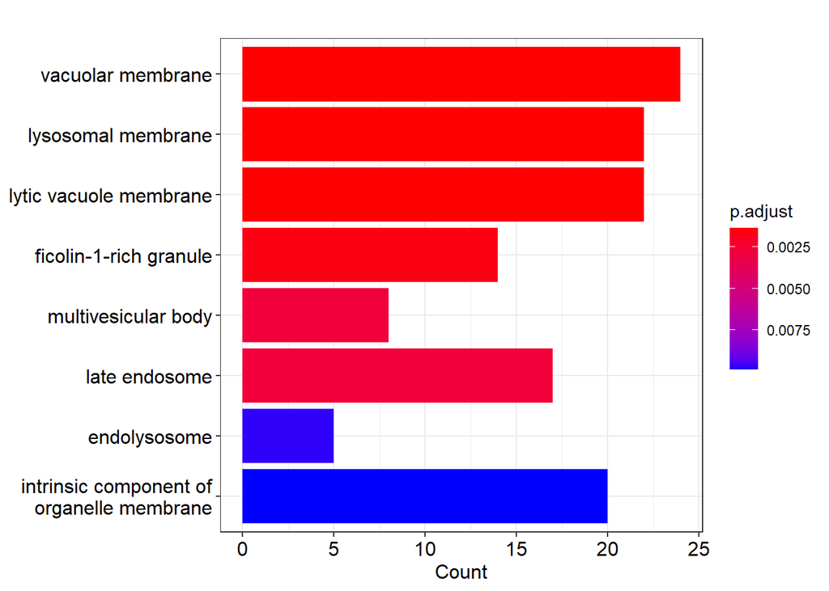

```r
barplot(go_overrepresentation_CC_AS_y_E)
```

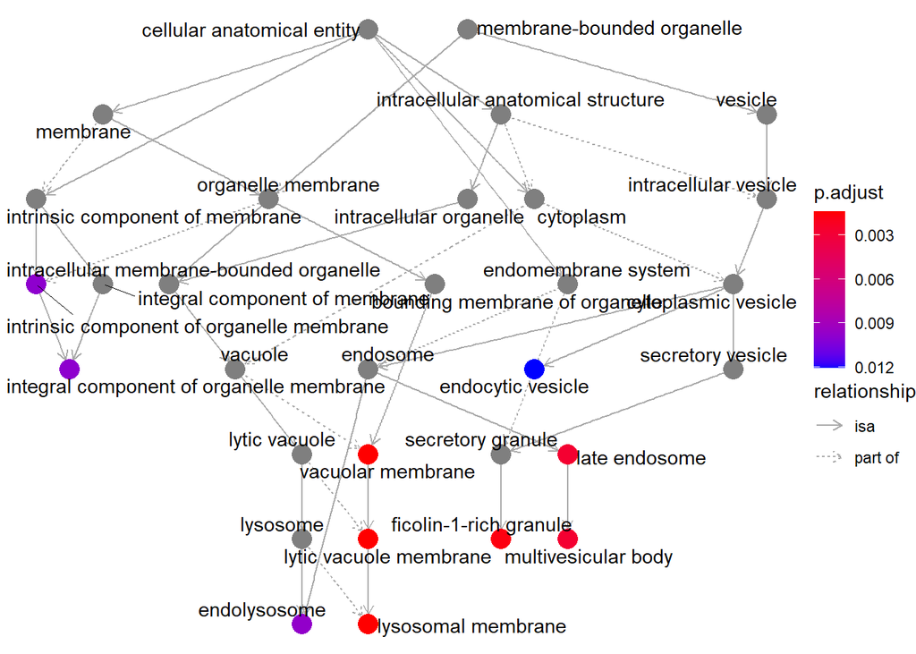

```r
goplot(go_overrepresentation_CC_AS_y_E)
```

### **GO Molecular Function** - GO classification

```r
gg_MF_AS_y_E <- groupGO(gene = AS_y_E_ENTREZ,
                        OrgDb = org.Hs.eg.db,
                        ont = "MF",
                        level = 3,
                        readable = TRUE)

head(gg_MF_AS_y_E)
```

```
##                    ID                               Description Count GeneRatio
## GO:0000146 GO:0000146              microfilament motor activity     1     1/393
## GO:0003777 GO:0003777                microtubule motor activity     0     0/393
## GO:0061791 GO:0061791                     GTPase motor activity     0     0/393
## GO:0140605 GO:0140605 proton motive force-driven motor activity     0     0/393
## GO:0004133 GO:0004133      glycogen debranching enzyme activity     0     0/393
## GO:0009975 GO:0009975                          cyclase activity     0     0/393
##            geneID
## GO:0000146   MYH9
## GO:0003777
## GO:0061791
## GO:0140605
## GO:0004133
## GO:0009975
```

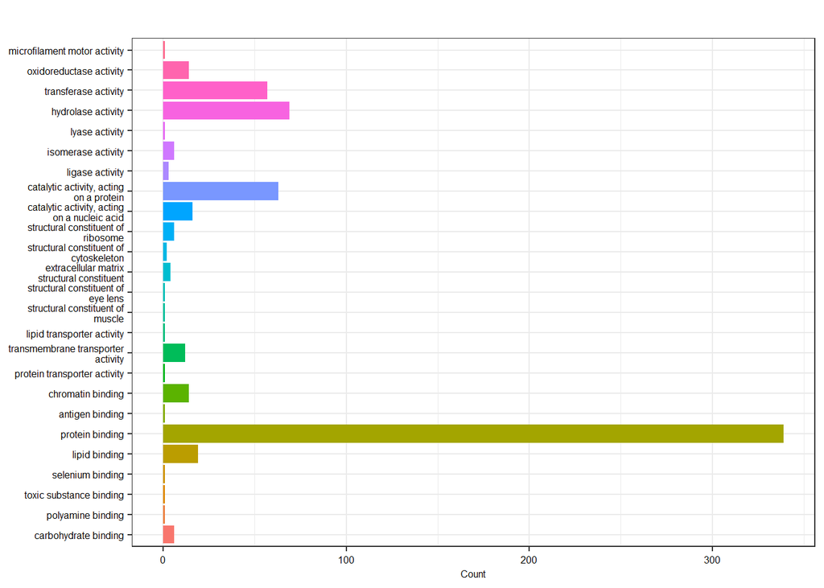

```r
barplot(gg_MF_AS_y_E, drop=TRUE, showCategory=25, vertex.label.cex=0.8, font = 6)
```

### **GO Molecular Function** - Go Over-representation analysis

```r
go_overrepresentation_MF_AS_y_E <- enrichGO(gene = AS_y_E_ENTREZ,
                                            OrgDb = org.Hs.eg.db,
                                            ont = "MF",
                                            pAdjustMethod = "BH",
                                            pvalueCutoff = 0.05,
                                            qvalueCutoff = 0.2,
                                            readable = TRUE)
head(go_overrepresentation_MF_AS_y_E)
```

```
##                    ID                            Description GeneRatio
## GO:0045296 GO:0045296                       cadherin binding    21/383
## GO:0030674 GO:0030674 protein-macromolecule adaptor activity    18/383
##              BgRatio       pvalue   p.adjust      qvalue
## GO:0045296 332/18368 7.075118e-06 0.00446440 0.004125911
## GO:0030674 296/18368 5.334907e-05 0.01683163 0.015555466
##                                                                                                                                 geneID
## GO:0045296 RTN4/PPP1CA/NOTCH3/PFKP/PLCB3/CSNK1D/ABCF3/KRT18/PUF60/EMD/SCYL1/ITGA6/RAB11B/MYH9/TXNDC9/OLA1/TES/LYPLA2/BSG/SHTN1/EPS15L1
## GO:0030674                          AP2M1/TRADD/CBX5/CUX1/APH1A/CRK/AP2A2/AP1S1/MYH9/SRRT/STX18/MAP2K2/OPTN/MAP2K1/USE1/CAV1/SHC1/DVL2
##            Count
## GO:0045296    21
## GO:0030674    18
```

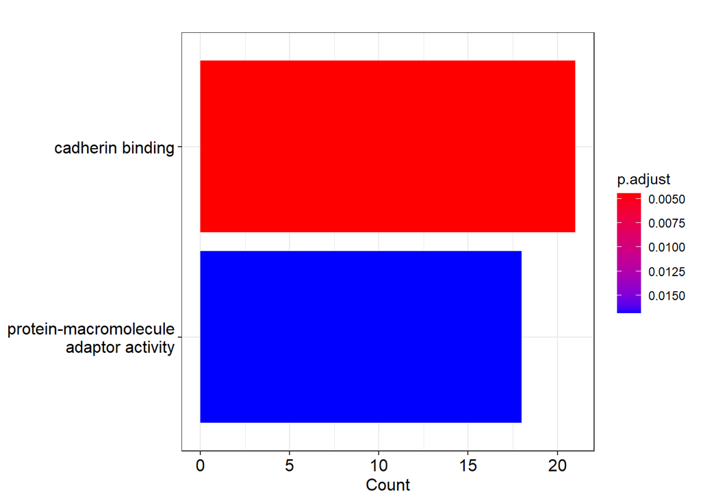

```r
barplot(go_overrepresentation_MF_AS_y_E)
```

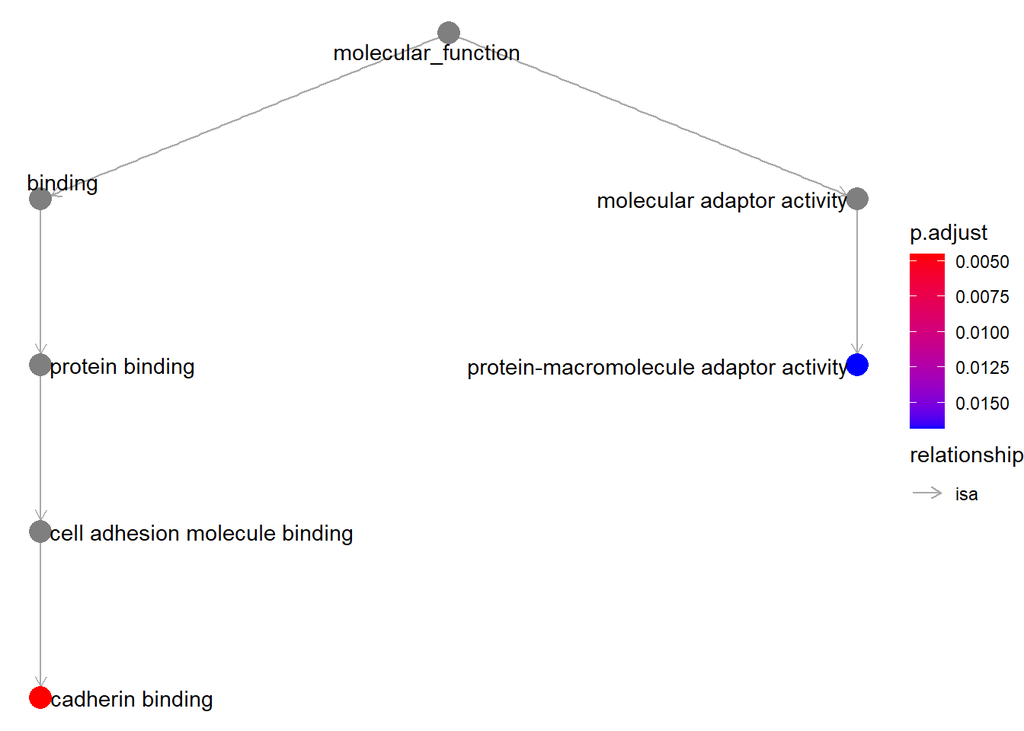

```r
goplot(go_overrepresentation_MF_AS_y_E)
```

### **GO Biological Process** - GO classification

```r
gg_BP_AS_y_E <- groupGO(gene = AS_y_E_ENTREZ,
                        OrgDb = org.Hs.eg.db,
                        ont = "BP",
                        level = 3,
                        readable = TRUE)

head(gg_BP_AS_y_E)
```

```
##                    ID                              Description Count GeneRatio
## GO:0019953 GO:0019953                      sexual reproduction    11    11/393
## GO:0019954 GO:0019954                     asexual reproduction     0     0/393
## GO:0022414 GO:0022414                     reproductive process    22    22/393
## GO:0032504 GO:0032504      multicellular organism reproduction    11    11/393
## GO:0032505 GO:0032505 reproduction of a single-celled organism     0     0/393
## GO:0075325 GO:0075325                          spore dispersal     0     0/393
##                                                                                                                                  geneID
## GO:0019953                                                              DYNLL1/BCKDK/MDK/MYH9/CREM/DAZAP1/CCT5/PAFAH1B3/FAM50A/CALR/BAD
## GO:0019954
## GO:0022414 STK3/SPINT2/TNFSF10/PHB2/DYNLL1/BCKDK/PTK2/MDK/MYH9/CREM/HUS1/FOS/DAZAP1/CCT5/PAFAH1B3/FAM50A/MAP2K1/BSG/SIRT7/CALR/MED1/BAD
## GO:0032504                                                               DYNLL1/BCKDK/MDK/CREM/DAZAP1/PAFAH1B3/FAM50A/BSG/CALR/MED1/BAD
## GO:0032505
## GO:0075325
```

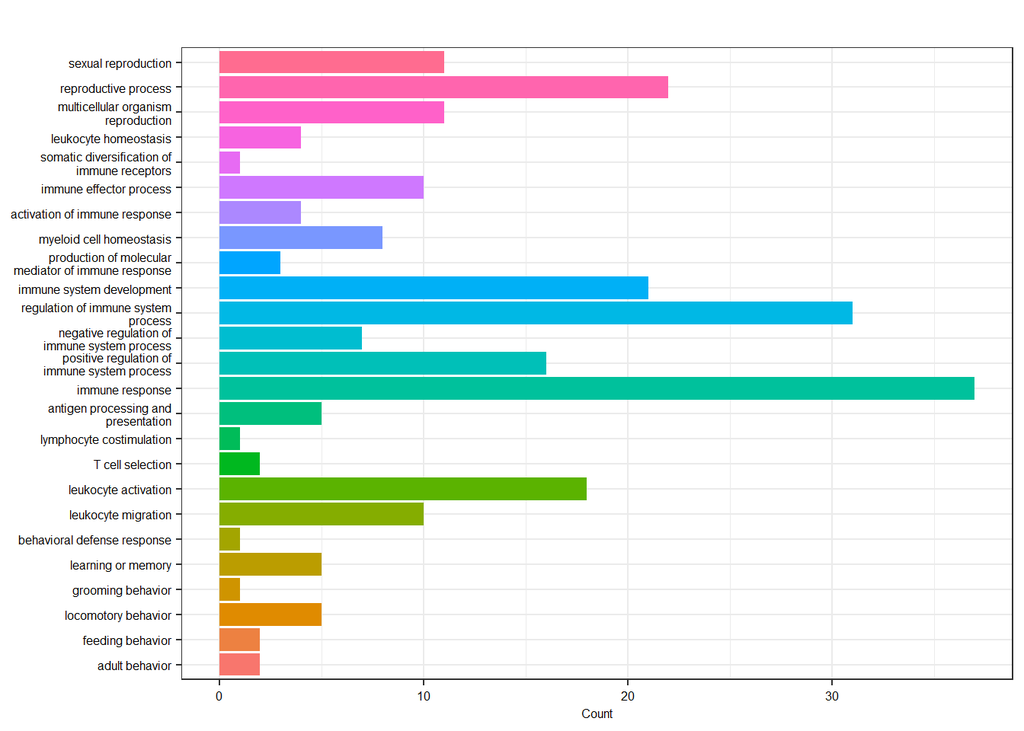

```r
barplot(gg_BP_AS_y_E, drop=TRUE, showCategory=25, vertex.label.cex=0.8, font = 6)
```

### **GO Biological Process** - Go Over-representation analysis

```r
go_overrepresentation_BP_AS_y_E <- enrichGO(gene = AS_y_E_ENTREZ,
                                            OrgDb = org.Hs.eg.db,
                                            ont = "BP",
                                            pAdjustMethod = "BH",
                                            pvalueCutoff = 0.05,
                                            qvalueCutoff = 0.2,
                                            readable = TRUE)
head(go_overrepresentation_BP_AS_y_E)
```

```
##                    ID                                 Description GeneRatio
## GO:0050684 GO:0050684               regulation of mRNA processing    13/368
## GO:0032206 GO:0032206 positive regulation of telomere maintenance     8/368
## GO:0043484 GO:0043484                  regulation of RNA splicing    13/368
## GO:0007249 GO:0007249         I-kappaB kinase/NF-kappaB signaling    18/368
## GO:1903008 GO:1903008                       organelle disassembly    11/368
## GO:0008380 GO:0008380                                RNA splicing    23/368
##              BgRatio       pvalue    p.adjust      qvalue
## GO:0050684 137/18723 3.144719e-06 0.007868916 0.007277819
## GO:0032206  52/18723 7.301350e-06 0.007868916 0.007277819
## GO:0043484 148/18723 7.393739e-06 0.007868916 0.007277819
## GO:0007249 281/18723 1.232720e-05 0.007868916 0.007277819
## GO:1903008 114/18723 1.537267e-05 0.007868916 0.007277819
## GO:0008380 434/18723 1.782140e-05 0.007868916 0.007277819
##                                                                                                                                                          geneID
## GO:0050684                                                                   CDK11B/RBM10/HNRNPA1/CIRBP/ZC3H3/SFSWAP/PUF60/NCBP2/PAPOLA/DAZAP1/FXR2/RBMX/RBFOX2
## GO:0032206                                                                                                   ACD/HNRNPA1/NABP2/DKC1/PNKP/CCT5/HNRNPA2B1/PPP1R10
## GO:0043484                                                                     RBM10/HNRNPA1/CIRBP/SFSWAP/PUF60/RBM38/DAZAP1/FAM50A/FXR2/CLK2/FASTK/RBMX/RBFOX2
## GO:0007249                                   MIB2/LTBR/IKBKG/TNFSF10/UBE2I/BST2/TRADD/USP10/JMJD8/CXXC5/TNFRSF1A/TMEM101/TNIP2/NFKBIA/OPTN/RIPK2/TSPAN6/NFKBIL1
## GO:1903008                                                                                 BNIP3L/SLC25A5/MAP1LC3A/PHB2/FUNDC1/HDAC6/BNIP3/OPTN/KLC1/HTRA2/PELO
## GO:0008380 HTATSF1/RBM10/HNRNPA1/CIRBP/SNRPD3/SFSWAP/PUF60/CD2BP2/SCNM1/LSM4/NCBP2/RBM38/DAZAP1/FAM50A/FXR2/CLK2/AAR2/FASTK/HNRNPA2B1/RBMX/SNRNP200/RBFOX2/LSM2
##            Count
## GO:0050684    13
## GO:0032206     8
## GO:0043484    13
## GO:0007249    18
## GO:1903008    11
## GO:0008380    23
```

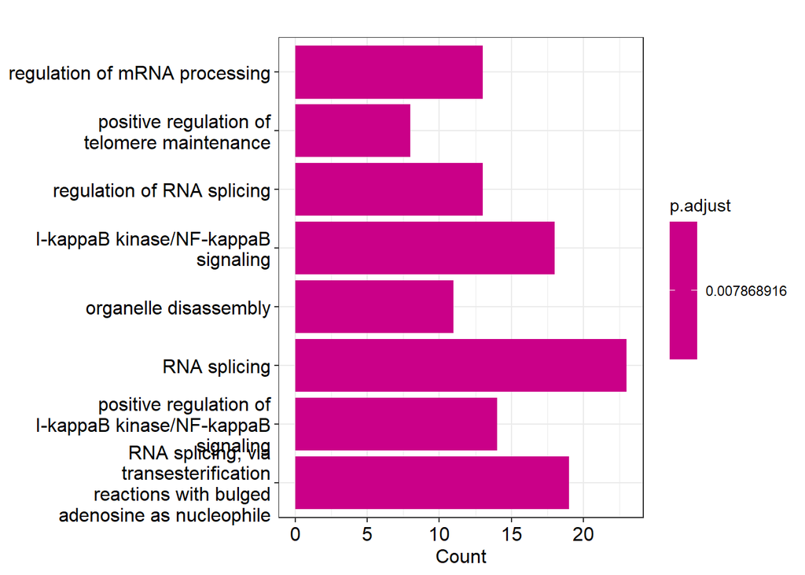

```r
barplot(go_overrepresentation_BP_AS_y_E)
```

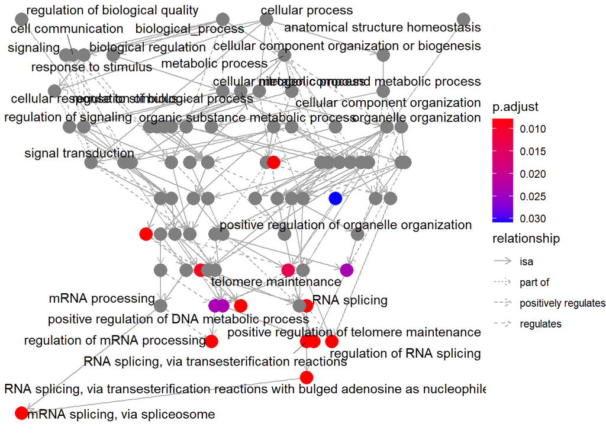

```r
goplot(go_overrepresentation_BP_AS_y_E)
```

# Grupo **Alternative Splicing but not Expression related (AS y not E)**

```r
AS_y_notE_df <- Datos_limpios %>%
  dplyr::filter(Pv_wilcox < 0.05,
                P.Value > 0.05)

Lista_genes_AS_y_notE <- unique(AS_y_notE_df$Gene)

AS_y_notE_ENTREZ <- mapIds(org.Hs.eg.db, Lista_genes_AS_y_notE, 'ENTREZID', 'SYMBOL')
```

### **GO Celular Component** - GO classification

```r
gg_CC_AS_y_notE <- groupGO(gene = AS_y_notE_ENTREZ,
                        OrgDb = org.Hs.eg.db,
                        ont = "CC",
                        level = 3,
                        readable = TRUE)

head(gg_CC_AS_y_notE)
```

```
##                    ID                Description Count GeneRatio geneID
## GO:0000133 GO:0000133                 polarisome     0      0/98
## GO:0000408 GO:0000408          EKC/KEOPS complex     0      0/98
## GO:0000417 GO:0000417                HIR complex     0      0/98
## GO:0000444 GO:0000444    MIS12/MIND type complex     0      0/98
## GO:0000808 GO:0000808 origin recognition complex     0      0/98
## GO:0000930 GO:0000930      gamma-tubulin complex     0      0/98
```

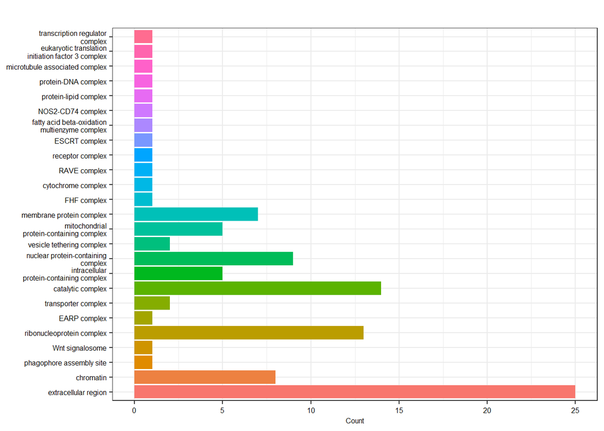

```r
barplot(gg_CC_AS_y_notE, drop=TRUE, showCategory=25, vertex.label.cex=0.8, font = 6)
```

### **GO Celular Component** - Go Over-representation analysis

```r
go_overrepresentation_CC_AS_y_notE <- enrichGO(gene = AS_y_notE_ENTREZ,
                                            OrgDb = org.Hs.eg.db,
                                            ont = "CC",
                                            pAdjustMethod = "BH",
                                            pvalueCutoff = 0.05,
                                            qvalueCutoff = 0.2,
                                            readable = TRUE)
head(go_overrepresentation_CC_AS_y_notE)
```

```
##                    ID                      Description GeneRatio   BgRatio
## GO:0022626 GO:0022626               cytosolic ribosome      6/95 102/19550
## GO:0005840 GO:0005840                         ribosome      8/95 240/19550
## GO:0044391 GO:0044391                ribosomal subunit      7/95 180/19550
## GO:0070603 GO:0070603 SWI/SNF superfamily-type complex      4/95  72/19550
## GO:1904949 GO:1904949                   ATPase complex      4/95  73/19550
## GO:0005759 GO:0005759             mitochondrial matrix      9/95 480/19550
##                  pvalue    p.adjust      qvalue
## GO:0022626 1.038319e-05 0.002286395 0.002083878
## GO:0005840 2.225850e-05 0.002286395 0.002083878
## GO:0044391 2.788287e-05 0.002286395 0.002083878
## GO:0070603 4.180496e-04 0.021679995 0.019759687
## GO:1904949 4.406503e-04 0.021679995 0.019759687
## GO:0005759 5.456097e-04 0.022369998 0.020388573
##                                                          geneID Count
## GO:0022626                  RPL5/RPS15A/RPS8/RPL23A/RPS18/RPL17     6
## GO:0005840    RPL5/RPS15A/RPS8/RPL23A/LARP4B/RPS18/RPL17/MRPL33     8
## GO:0044391           RPL5/RPS15A/RPS8/RPL23A/RPS18/RPL17/MRPL33     7
## GO:0070603                            ARID1B/PHF10/INO80C/NFRKB     4
## GO:1904949                            ARID1B/PHF10/INO80C/NFRKB     4
## GO:0005759 TMLHE/HMGCL/SOD2/HADHA/MRPL33/PDHX/BDH1/NDUFS3/VDAC1     9
```

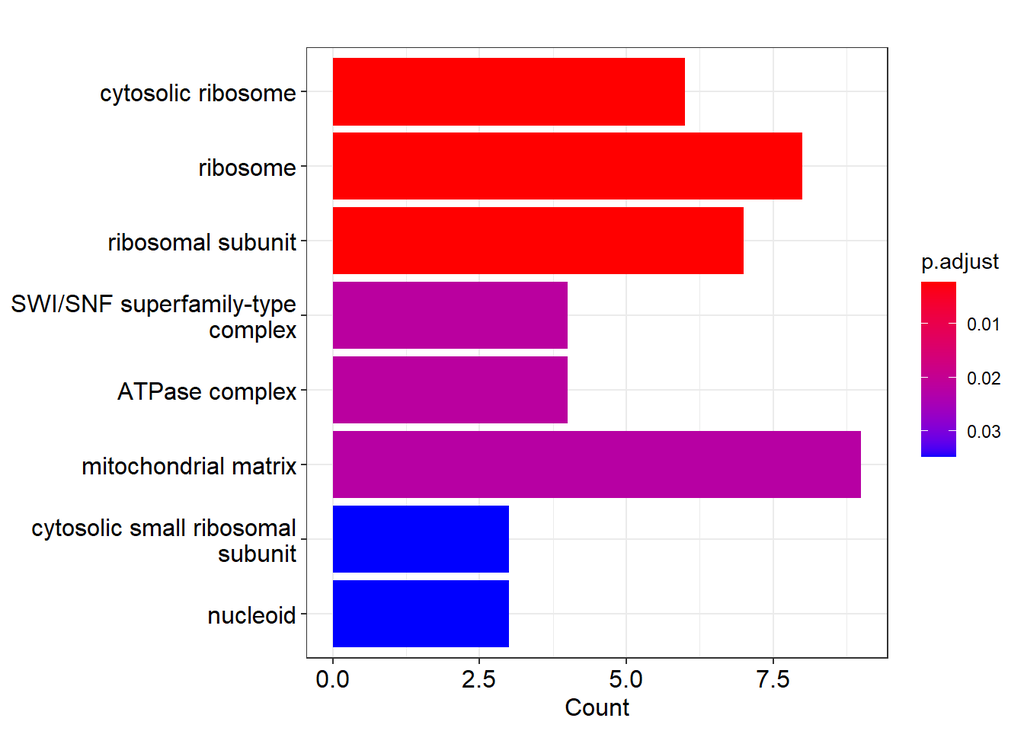

```r
barplot(go_overrepresentation_CC_AS_y_notE)
```

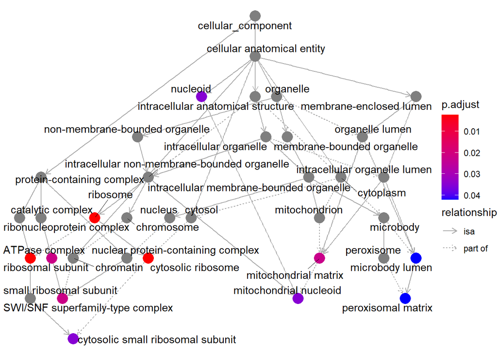

```r
goplot(go_overrepresentation_CC_AS_y_notE)
```

### **GO Molecular Function** - GO classification

```r
gg_MF_AS_y_notE <- groupGO(gene = AS_y_notE_ENTREZ,
                        OrgDb = org.Hs.eg.db,
                        ont = "MF",
                        level = 3,
                        readable = TRUE)

head(gg_MF_AS_y_notE)
```

```
##                    ID                               Description Count GeneRatio
## GO:0000146 GO:0000146              microfilament motor activity     0      0/98
## GO:0003777 GO:0003777                microtubule motor activity     0      0/98
## GO:0061791 GO:0061791                     GTPase motor activity     0      0/98
## GO:0140605 GO:0140605 proton motive force-driven motor activity     0      0/98
## GO:0004133 GO:0004133      glycogen debranching enzyme activity     0      0/98
## GO:0009975 GO:0009975                          cyclase activity     0      0/98
##            geneID
## GO:0000146
## GO:0003777
## GO:0061791
## GO:0140605
## GO:0004133
## GO:0009975
```

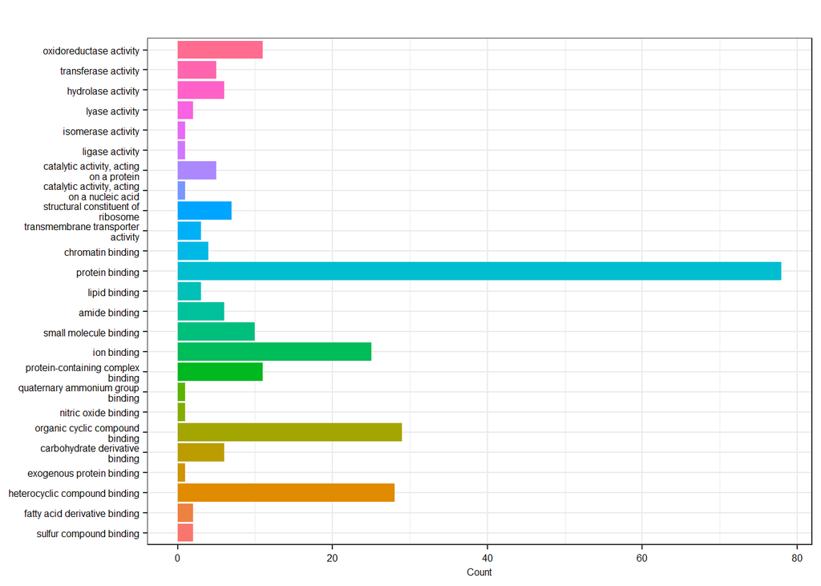

```r
barplot(gg_MF_AS_y_notE, drop=TRUE, showCategory=25, vertex.label.cex=0.8, font = 6)
```

### **GO Molecular Function** - Go Over-representation analysis

```r
go_overrepresentation_MF_AS_y_notE <- enrichGO(gene = AS_y_notE_ENTREZ,
                                            OrgDb = org.Hs.eg.db,
                                            ont = "MF",
                                            pAdjustMethod = "BH",
                                            pvalueCutoff = 0.05,
                                            qvalueCutoff = 0.2,
                                            readable = TRUE)
head(go_overrepresentation_MF_AS_y_notE)
```

```
##                    ID
## GO:0003735 GO:0003735
## GO:0019843 GO:0019843
## GO:0016616 GO:0016616
## GO:0016614 GO:0016614
##                                                                                      Description
## GO:0003735                                                    structural constituent of ribosome
## GO:0019843                                                                          rRNA binding
## GO:0016616 oxidoreductase activity, acting on the CH-OH group of donors, NAD or NADP as acceptor
## GO:0016614                              oxidoreductase activity, acting on CH-OH group of donors
##            GeneRatio   BgRatio       pvalue    p.adjust      qvalue
## GO:0003735      7/91 182/18368 3.354734e-05 0.008051362 0.007415728
## GO:0019843      4/91  68/18368 3.603510e-04 0.030262436 0.027873296
## GO:0016616      5/91 124/18368 3.782804e-04 0.030262436 0.027873296
## GO:0016614      5/91 136/18368 5.772561e-04 0.034635364 0.031900993
##                                                geneID Count
## GO:0003735 RPL5/RPS15A/RPS8/RPL23A/RPS18/RPL17/MRPL33     7
## GO:0019843                    RPL5/RPL23A/RPS18/GTF3A     4
## GO:0016616              HADHA/DHRS7B/GRHPR/BDH1/DHRS4     5
## GO:0016614              HADHA/DHRS7B/GRHPR/BDH1/DHRS4     5
```

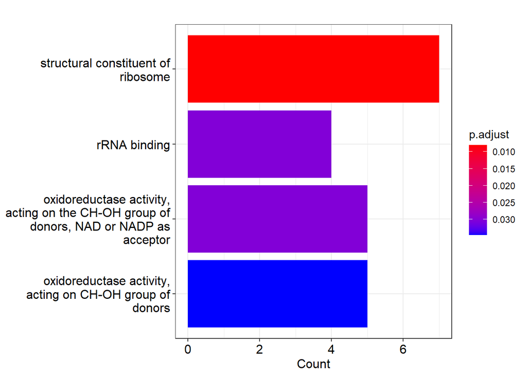

```r
barplot(go_overrepresentation_MF_AS_y_notE)
```

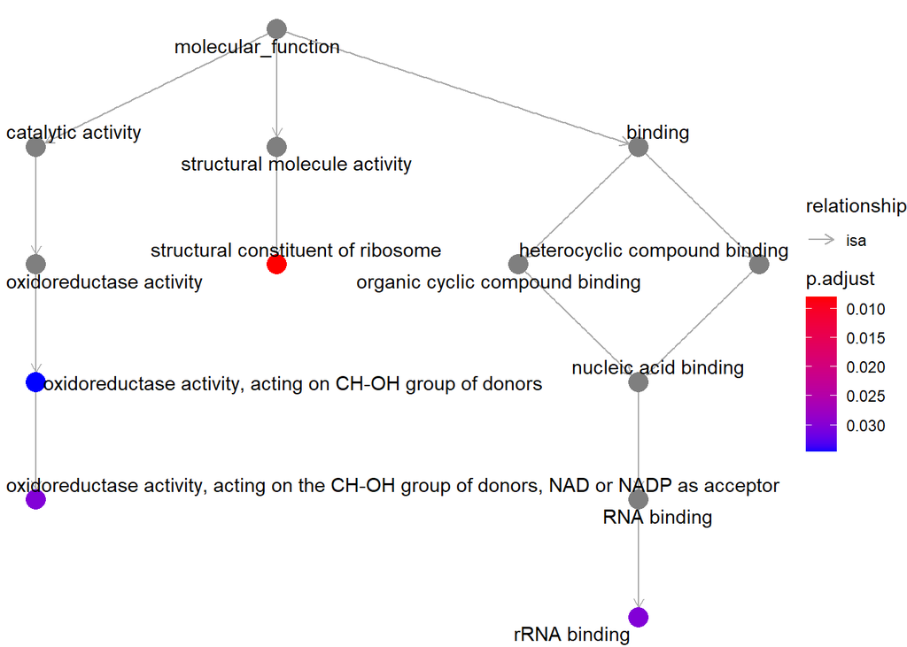

```r
goplot(go_overrepresentation_MF_AS_y_notE)
```

### **GO Biological Process** - GO classification

```r
gg_BP_AS_y_notE <- groupGO(gene = AS_y_notE_ENTREZ,
                        OrgDb = org.Hs.eg.db,
                        ont = "BP",
                        level = 3,
                        readable = TRUE)

head(gg_BP_AS_y_notE)
```

```
##                    ID                              Description Count GeneRatio
## GO:0019953 GO:0019953                      sexual reproduction     0      0/98
## GO:0019954 GO:0019954                     asexual reproduction     0      0/98
## GO:0022414 GO:0022414                     reproductive process     5      5/98
## GO:0032504 GO:0032504      multicellular organism reproduction     2      2/98
## GO:0032505 GO:0032505 reproduction of a single-celled organism     0      0/98
## GO:0075325 GO:0075325                          spore dispersal     0      0/98
##                                     geneID
## GO:0019953
## GO:0019954
## GO:0022414 SUN2/ST14/SERPINF1/STAT5B/CRIP1
## GO:0032504                 SERPINF1/STAT5B
## GO:0032505
## GO:0075325
```

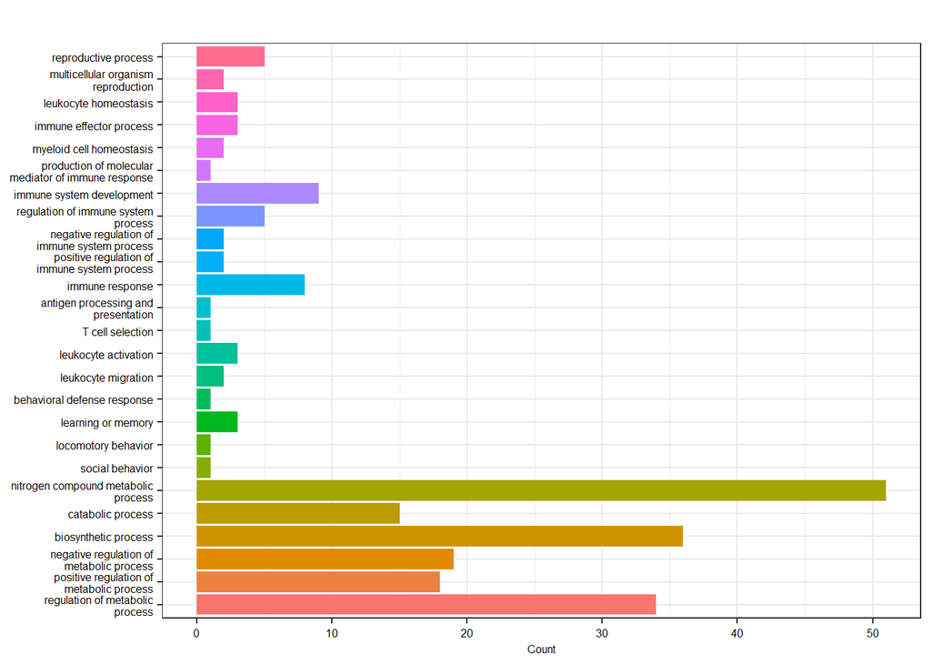

```r
barplot(gg_BP_AS_y_notE, drop=TRUE, showCategory=25, vertex.label.cex=0.8, font = 6)
```

### **GO Biological Process** - Go Over-representation analysis

```r
go_overrepresentation_BP_AS_y_notE <- enrichGO(gene = AS_y_notE_ENTREZ,
                                            OrgDb = org.Hs.eg.db,
                                            ont = "BP",
                                            pAdjustMethod = "BH",
                                            pvalueCutoff = 0.05,
                                            qvalueCutoff = 0.2,
                                            readable = TRUE)
head(go_overrepresentation_BP_AS_y_notE)
```

```
##                    ID                        Description GeneRatio   BgRatio
## GO:0002181 GO:0002181            cytoplasmic translation      7/91 148/18723
## GO:0042273 GO:0042273 ribosomal large subunit biogenesis      5/91  72/18723
##                  pvalue   p.adjust     qvalue
## GO:0002181 7.774184e-06 0.01407905 0.01342070
## GO:0042273 2.627359e-05 0.02379073 0.02267825
##                                               geneID Count
## GO:0002181 EIF3K/RPL5/RPS15A/RPS8/RPL23A/RPS18/RPL17     7
## GO:0042273             RPL5/ZNHIT6/RPL23A/NHP2/GTF3A     5
```

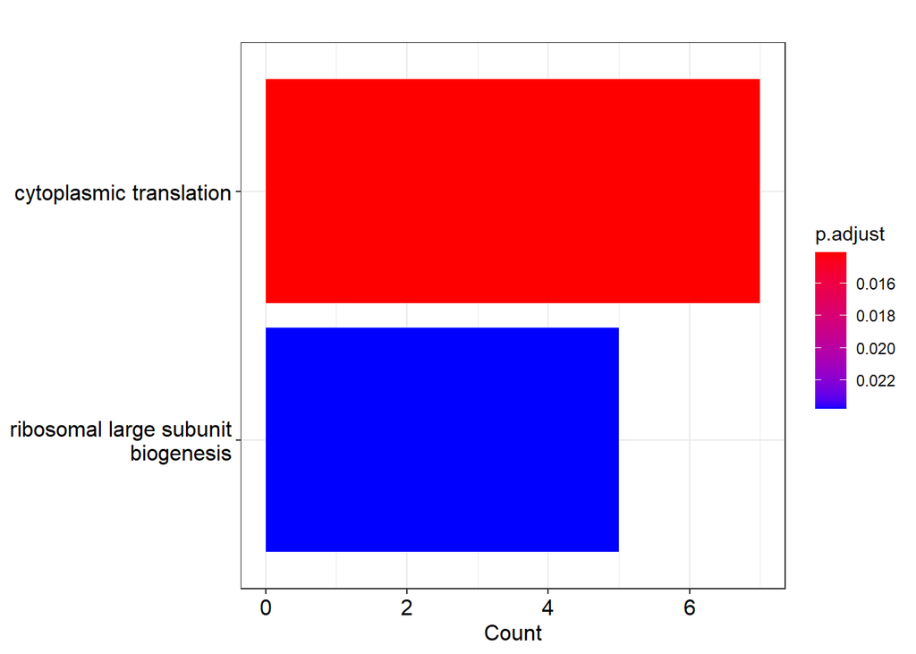

```r
barplot(go_overrepresentation_BP_AS_y_notE)
```

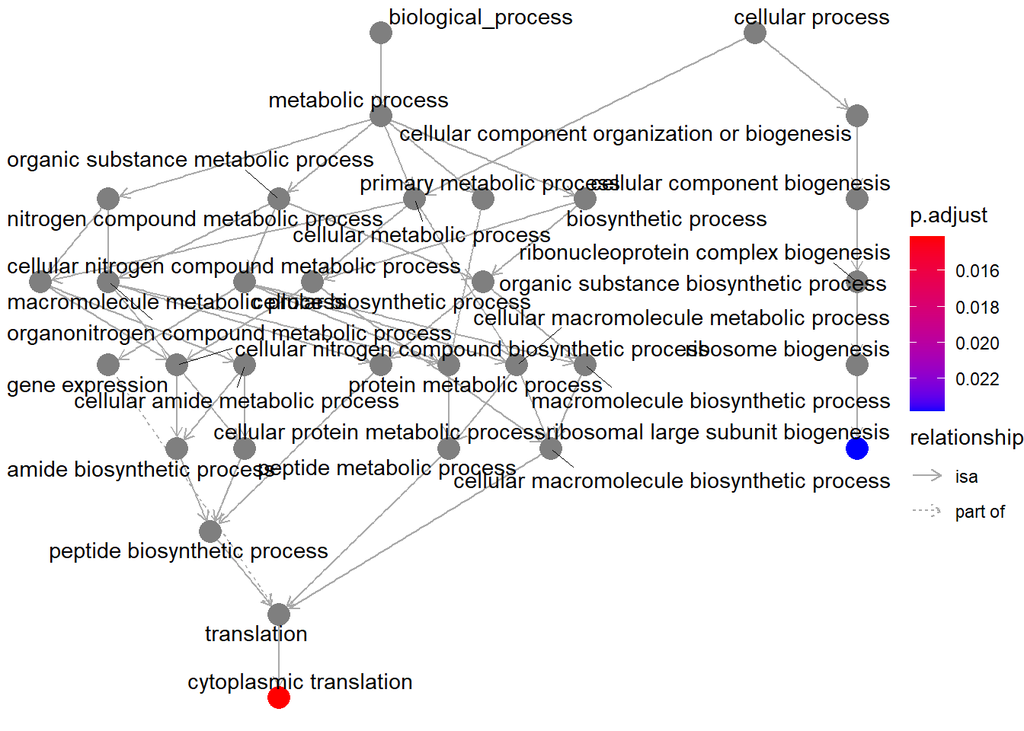

```r
goplot(go_overrepresentation_BP_AS_y_notE)
```

# Grupo **Related with Alternative Splicing (no focus on Expression) (AS related)**

```r
AS_related_df <- Datos_limpios %>%
  dplyr::filter(Pv_wilcox < 0.05)

Lista_genes_AS_related <- unique(AS_related_df$Gene)

AS_related_ENTREZ <- mapIds(org.Hs.eg.db, Lista_genes_AS_related, 'ENTREZID', 'SYMBOL')
```

### **GO Celular Component** - GO classification

```r
gg_CC_AS_related <- groupGO(gene = AS_related_ENTREZ,
                           OrgDb = org.Hs.eg.db,
                           ont = "CC",
                           level = 3,
                           readable = TRUE)

head(gg_CC_AS_related)
```

```
##                    ID                Description Count GeneRatio geneID
## GO:0000133 GO:0000133                 polarisome     0     0/490
## GO:0000408 GO:0000408          EKC/KEOPS complex     0     0/490
## GO:0000417 GO:0000417                HIR complex     0     0/490
## GO:0000444 GO:0000444    MIS12/MIND type complex     0     0/490
## GO:0000808 GO:0000808 origin recognition complex     0     0/490
## GO:0000930 GO:0000930      gamma-tubulin complex     0     0/490
```

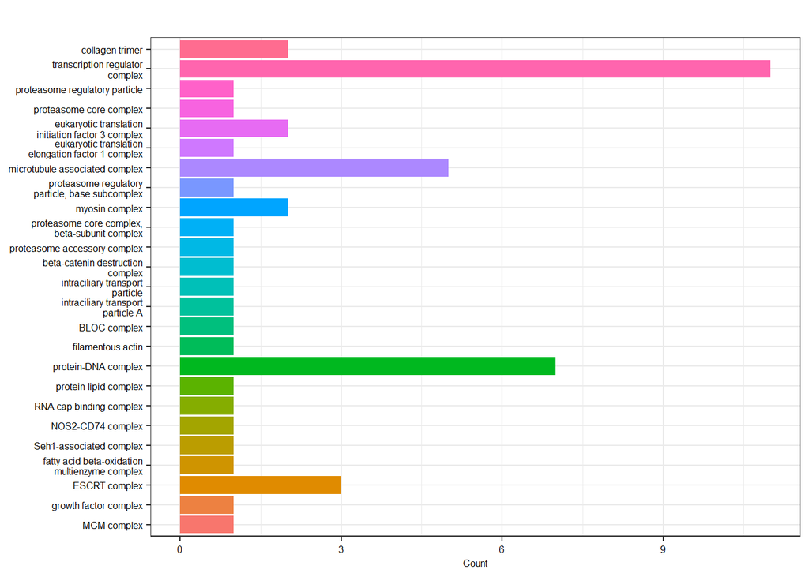

```r
barplot(gg_CC_AS_related, drop=TRUE, showCategory=25, vertex.label.cex=0.8, font = 6)
```

### **GO Celular Component** - Go Over-representation analysis

```r
go_overrepresentation_CC_AS_related <- enrichGO(gene = AS_related_ENTREZ,
                                               OrgDb = org.Hs.eg.db,
                                               ont = "CC",
                                               pAdjustMethod = "BH",
                                               pvalueCutoff = 0.05,
                                               qvalueCutoff = 0.2,
                                               readable = TRUE)
head(go_overrepresentation_CC_AS_related)
```

```
##                    ID            Description GeneRatio   BgRatio       pvalue
## GO:0101002 GO:0101002 ficolin-1-rich granule    17/470 185/19550 2.523845e-06
## GO:0005770 GO:0005770          late endosome    20/470 282/19550 1.754289e-05
## GO:0005771 GO:0005771    multivesicular body     9/470  64/19550 2.117668e-05
## GO:0005840 GO:0005840               ribosome    18/470 240/19550 2.187135e-05
## GO:0005774 GO:0005774      vacuolar membrane    26/470 444/19550 3.024177e-05
## GO:0005765 GO:0005765     lysosomal membrane    24/470 395/19550 3.395922e-05
##               p.adjust      qvalue
## GO:0101002 0.001312399 0.001020165
## GO:0005770 0.002522685 0.001960953
## GO:0005771 0.002522685 0.001960953
## GO:0005840 0.002522685 0.001960953
## GO:0005774 0.002522685 0.001960953
## GO:0005765 0.002522685 0.001960953
##                                                                                                                                                                               geneID
## GO:0101002                                                                         PSMD2/HSPA1A/ATG7/FTH1/GSDMD/DYNLL1/AP2A2/CAB39/ACLY/CTSH/TCIRG1/EEF1A1/RAC1/GSN/CST3/C1orf35/GAA
## GO:0005770                                            RNF13/BST2/CD74/MAP1LC3A/CYB561A3/VPS28/TPT1/IFITM2/CTSH/TCIRG1/CHID1/RAB9A/HDAC6/CTSL/MAP2K2/PRKAR1B/VPS37B/HGS/MAP2K1/RAB11A
## GO:0005771                                                                                                                         BST2/CD74/TPT1/CTSH/HDAC6/CTSL/PRKAR1B/HGS/RAB11A
## GO:0005840                                                        RPL5/RPS15A/RPL36A/MRPS21/RPS8/RPL23A/RPS27A/LARP4B/RPS18/ABCF1/MRPS22/RPL17/MRPL33/FXR2/EIF3H/AURKAIP1/RPSA/MRPL4
## GO:0005774 AP2M1/RNF13/BST2/CD74/MAP1LC3A/TPCN1/NEU1/RAB12/CYB561A3/SLC35F6/RAB5C/SPPL2B/SLC15A4/AP2A2/GLMP/BORCS5/IFITM2/AP1S1/SNAPIN/WDR24/TCIRG1/EEF1A1/CCDC115/RHEB/GAA/ATP6V0E1
## GO:0005765                  AP2M1/RNF13/BST2/CD74/TPCN1/NEU1/RAB12/CYB561A3/SLC35F6/RAB5C/SPPL2B/SLC15A4/AP2A2/GLMP/BORCS5/IFITM2/AP1S1/SNAPIN/WDR24/TCIRG1/EEF1A1/RHEB/GAA/ATP6V0E1
##            Count
## GO:0101002    17
## GO:0005770    20
## GO:0005771     9
## GO:0005840    18
## GO:0005774    26
## GO:0005765    24
```

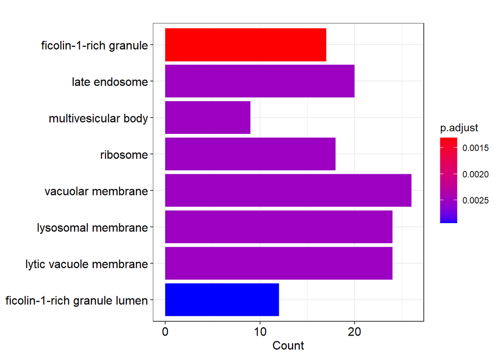

```r
barplot(go_overrepresentation_CC_AS_related)
```

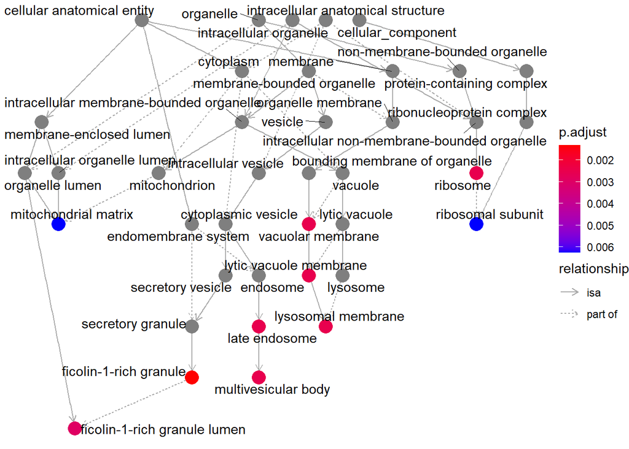

```r
goplot(go_overrepresentation_CC_AS_related)
```

### **GO Molecular Function** - GO classification

```r
gg_MF_AS_related <- groupGO(gene = AS_related_ENTREZ,
                           OrgDb = org.Hs.eg.db,
                           ont = "MF",
                           level = 3,
                           readable = TRUE)

head(gg_MF_AS_related)
```

```
##                    ID                               Description Count GeneRatio
## GO:0000146 GO:0000146              microfilament motor activity     1     1/490
## GO:0003777 GO:0003777                microtubule motor activity     0     0/490
## GO:0061791 GO:0061791                     GTPase motor activity     0     0/490
## GO:0140605 GO:0140605 proton motive force-driven motor activity     0     0/490
## GO:0004133 GO:0004133      glycogen debranching enzyme activity     0     0/490
## GO:0009975 GO:0009975                          cyclase activity     0     0/490
##            geneID
## GO:0000146   MYH9
## GO:0003777
## GO:0061791
## GO:0140605
## GO:0004133
## GO:0009975
```

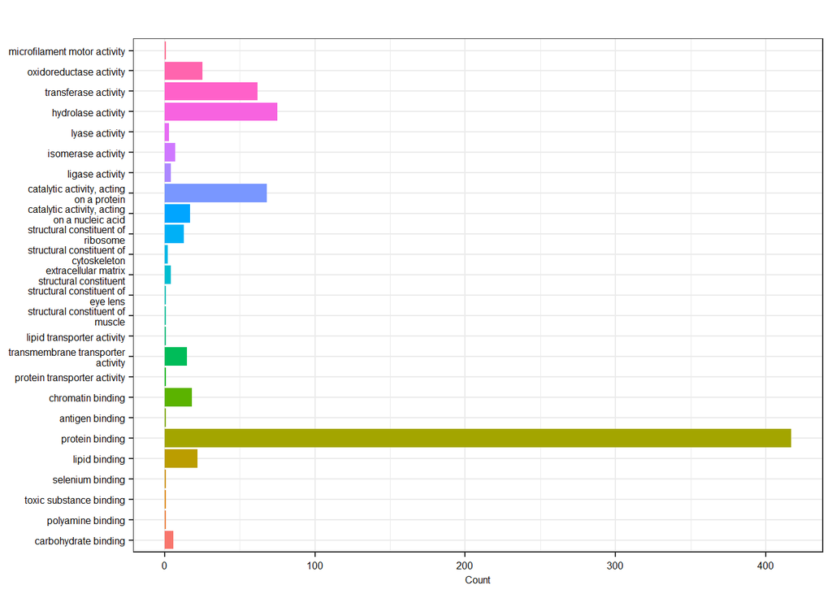

```r
barplot(gg_MF_AS_related, drop=TRUE, showCategory=25, vertex.label.cex=0.8, font = 6)
```

### **GO Molecular Function** - Go Over-representation analysis

```r
go_overrepresentation_MF_AS_related <- enrichGO(gene = AS_related_ENTREZ,
                                               OrgDb = org.Hs.eg.db,
                                               ont = "MF",
                                               pAdjustMethod = "BH",
                                               pvalueCutoff = 0.05,
                                               qvalueCutoff = 0.2,
                                               readable = TRUE)
head(go_overrepresentation_MF_AS_related)
```

```
##                    ID                            Description GeneRatio
## GO:0045296 GO:0045296                       cadherin binding    23/474
## GO:0030674 GO:0030674 protein-macromolecule adaptor activity    20/474
##              BgRatio       pvalue   p.adjust     qvalue
## GO:0045296 332/18368 1.885789e-05 0.01282337 0.01183085
## GO:0030674 296/18368 9.226145e-05 0.03136889 0.02894096
##                                                                                                                                               geneID
## GO:0045296 RTN4/PPP1CA/HSPA1A/NOTCH3/PFKP/PLCB3/CSNK1D/ABCF3/KRT18/RPL23A/PUF60/EMD/SCYL1/ITGA6/RAB11B/MYH9/TXNDC9/OLA1/TES/LYPLA2/BSG/SHTN1/EPS15L1
## GO:0030674                          AP2M1/SUN2/TRADD/CBX5/CUX1/APH1A/CRK/SLC9A3R1/AP2A2/AP1S1/MYH9/SRRT/STX18/MAP2K2/OPTN/MAP2K1/USE1/CAV1/SHC1/DVL2
##            Count
## GO:0045296    23
## GO:0030674    20
```

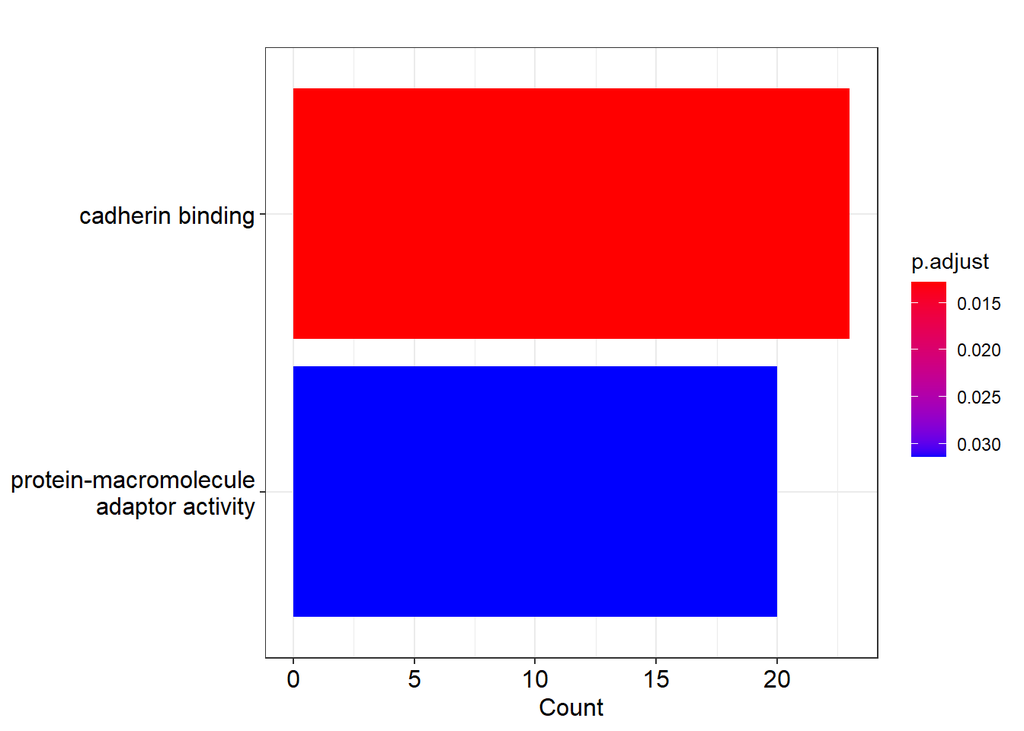

```r
barplot(go_overrepresentation_MF_AS_related)
```

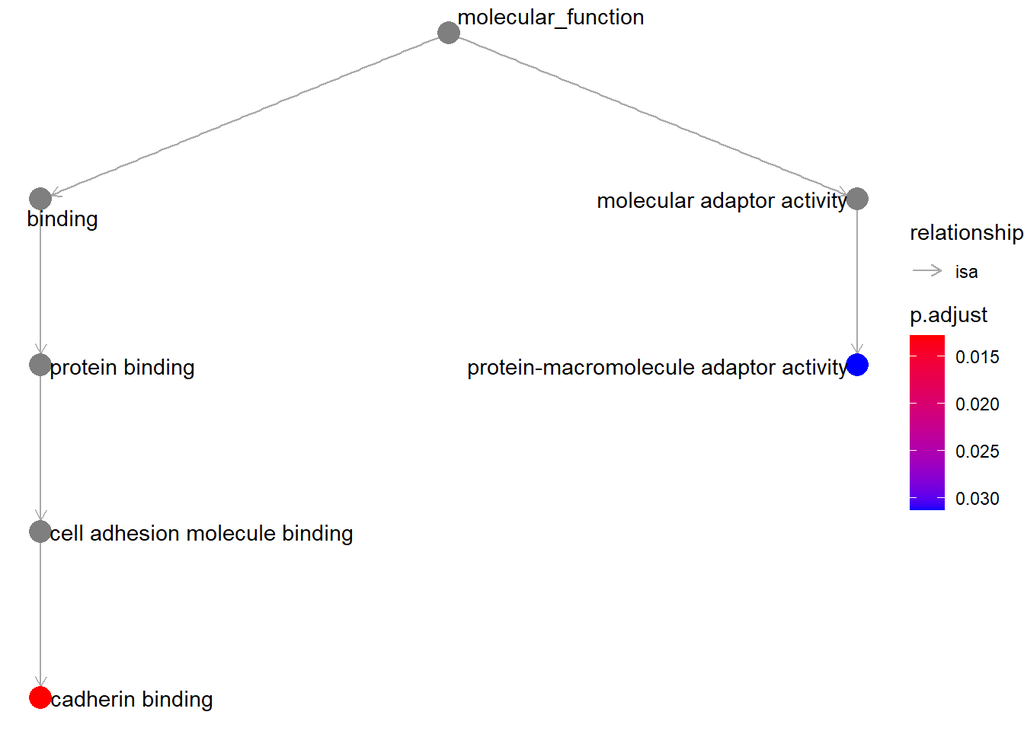

```r
goplot(go_overrepresentation_MF_AS_related)
```

### **GO Biological Process** - GO classification

```r
gg_BP_AS_related <- groupGO(gene = AS_related_ENTREZ,
                           OrgDb = org.Hs.eg.db,
                           ont = "BP",
                           level = 3,
                           readable = TRUE)

head(gg_BP_AS_related)
```

```
##                    ID                              Description Count GeneRatio
## GO:0019953 GO:0019953                      sexual reproduction    11    11/490
## GO:0019954 GO:0019954                     asexual reproduction     0     0/490
## GO:0022414 GO:0022414                     reproductive process    27    27/490
## GO:0032504 GO:0032504      multicellular organism reproduction    13    13/490
## GO:0032505 GO:0032505 reproduction of a single-celled organism     0     0/490
## GO:0075325 GO:0075325                          spore dispersal     0     0/490
##                                                                                                                                                                  geneID
## GO:0019953                                                                                              DYNLL1/BCKDK/MDK/MYH9/CREM/DAZAP1/CCT5/PAFAH1B3/FAM50A/CALR/BAD
## GO:0019954
## GO:0022414 STK3/SPINT2/SUN2/TNFSF10/PHB2/ST14/DYNLL1/BCKDK/PTK2/SERPINF1/MDK/MYH9/CREM/HUS1/FOS/DAZAP1/CCT5/PAFAH1B3/FAM50A/MAP2K1/BSG/SIRT7/STAT5B/CALR/MED1/BAD/CRIP1
## GO:0032504                                                                               DYNLL1/BCKDK/SERPINF1/MDK/CREM/DAZAP1/PAFAH1B3/FAM50A/BSG/STAT5B/CALR/MED1/BAD
## GO:0032505
## GO:0075325
```

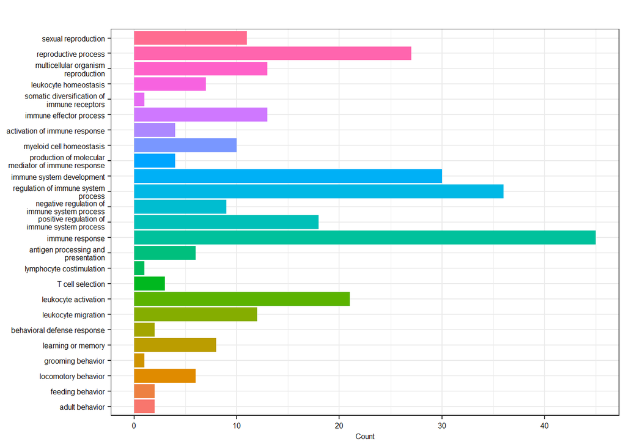

```r
barplot(gg_BP_AS_related, drop=TRUE, showCategory=25, vertex.label.cex=0.8, font = 6)
```